# Personal_Loan_Campaign_FINAL-JULY30

## Personal Loan Campaign Project

by Gracieli Scremin

### Description

#### Background and Context

AllLife Bank is a US bank that has a growing customer base. The majority of these customers are liability customers (depositors) with varying sizes of deposits. The number of customers who are also borrowers (asset customers) is quite small, and the bank is interested in expanding this base rapidly to bring in more loan business and in the process, earn more through the interest on loans. In particular, the management wants to explore ways of converting its liability customers to personal loan customers (while retaining them as depositors).

A campaign that the bank ran last year for liability customers showed a healthy conversion rate of over 9% success. This has encouraged the retail marketing department to devise campaigns with better target marketing to increase the success ratio.

You as a Data scientist at AllLife bank have to build a model that will help the marketing department to identify the potential customers who have a higher probability of purchasing the loan.

#### Objective

- To predict whether a liability customer will buy a personal loan or not.
- Which variables are most significant.
- Which segment of customers should be targeted more.

#### Data Dictionary

- ID: Customer ID
- Age: Customer’s age in completed years
- Experience: #years of professional experience
- Income: Annual income of the customer (in thousand dollars)
- ZIP Code: Home Address ZIP code.
- Family: the Family size of the customer
- CCAvg: Average spending on credit cards per month (in thousand dollars)
- Education: Education Level. 1: Undergrad; 2: Graduate;3: Advanced/Professional
- Mortgage: Value of house mortgage if any. (in thousand dollars)
- Personal_Loan: Did this customer accept the personal loan offered in the last campaign?
- Securities_Account: Does the customer have securities account with the bank?
- CD_Account: Does the customer have a certificate of deposit (CD) account with the bank?
- Online: Do customers use internet banking facilities?
- CreditCard: Does the customer use a credit card issued by any other Bank (excluding All life Bank)?

### Loading Libraries

```python
# Library to suppress warnings or deprecation notes
import warnings

warnings.filterwarnings("ignore")

# Libraries to help with reading and manipulating data

import pandas as pd
import numpy as np

# Library to split data
from sklearn.model_selection import train_test_split

# libaries to help with data visualization
import matplotlib.pyplot as plt
import seaborn as sns

# Removes the limit for the number of displayed columns
pd.set_option("display.max_columns", None)
# Sets the limit for the number of displayed rows
pd.set_option("display.max_rows", None)

# Libraries to build decision tree classifier
from sklearn.tree import DecisionTreeClassifier
from sklearn import tree

# To tune different models
from sklearn.model_selection import GridSearchCV

# To perform statistical analysis
import scipy.stats as stats

# To build model for prediction
import statsmodels.stats.api as sms
from statsmodels.stats.outliers_influence import variance_inflation_factor
import statsmodels.api as sm
from statsmodels.tools.tools import add_constant
from sklearn.linear_model import LogisticRegression

# To get diferent metric scores
from sklearn.metrics import (
    f1_score,
    accuracy_score,
    recall_score,
    precision_score,
    confusion_matrix,
    roc_auc_score,
    plot_confusion_matrix,
    precision_recall_curve,
    roc_curve,
    make_scorer,
)
```

### Loading the data

```python
loan_data = pd.read_csv("Loan_Modelling.csv")
```

```python
loan_data.head()
```

|  | ID | Age | Experience | Income | ZIPCode | Family | CCAvg | Education | Mortgage | Personal_Loan | Securities_Account | CD_Account | Online | CreditCard |
| --- | --- | --- | --- | --- | --- | --- | --- | --- | --- | --- | --- | --- | --- | --- |
| 0 | 1 | 25 | 1 | 49 | 91107 | 4 | 1.6 | 1 | 0 | 0 | 1 | 0 | 0 | 0 |
| 1 | 2 | 45 | 19 | 34 | 90089 | 3 | 1.5 | 1 | 0 | 0 | 1 | 0 | 0 | 0 |
| 2 | 3 | 39 | 15 | 11 | 94720 | 1 | 1.0 | 1 | 0 | 0 | 0 | 0 | 0 | 0 |
| 3 | 4 | 35 | 9 | 100 | 94112 | 1 | 2.7 | 2 | 0 | 0 | 0 | 0 | 0 | 0 |
| 4 | 5 | 35 | 8 | 45 | 91330 | 4 | 1.0 | 2 | 0 | 0 | 0 | 0 | 0 | 1 |

```python
df = loan_data.copy()
```

```python
df.shape
```

```
(5000, 14)
```

```python
df.info()
```

```
<class 'pandas.core.frame.DataFrame'>
RangeIndex: 5000 entries, 0 to 4999
Data columns (total 14 columns):
 #   Column              Non-Null Count  Dtype
---  ------              --------------  -----
 0   ID                  5000 non-null   int64
 1   Age                 5000 non-null   int64
 2   Experience          5000 non-null   int64
 3   Income              5000 non-null   int64
 4   ZIPCode             5000 non-null   int64
 5   Family              5000 non-null   int64
 6   CCAvg               5000 non-null   float64
 7   Education           5000 non-null   int64
 8   Mortgage            5000 non-null   int64
 9   Personal_Loan       5000 non-null   int64
 10  Securities_Account  5000 non-null   int64
 11  CD_Account          5000 non-null   int64
 12  Online              5000 non-null   int64
 13  CreditCard          5000 non-null   int64
dtypes: float64(1), int64(13)
memory usage: 547.0 KB
```

```python
df.isnull().sum()
```

```
ID                    0
Age                   0
Experience            0
Income                0
ZIPCode               0
Family                0
CCAvg                 0
Education             0
Mortgage              0
Personal_Loan         0
Securities_Account    0
CD_Account            0
Online                0
CreditCard            0
dtype: int64
```

#### Observations

- We observe that the original dataset has 5000 rows and 14 columns
- We also observe no missing values
- It looks like units of measurement are not recorded along with values which helps in pre-processing

##### Renaming variables for ease of interpretation

```python
df.rename(columns = {'Family': 'Family_Size',
                          'CCAvg': 'CreditCard_Spending',
                          'Mortgage': 'Mortgage_Value',
                          'Online': 'Online_Banking',
                          'CreditCard':'Other_CreditCard'}, inplace = True)
```

##### Enriching the dataset by adding information based on zipcode from uszipcode

```python
from uszipcode import SearchEngine #, Zipcode, SimpleZipcode
search = SearchEngine(simple_zipcode=True)

df['State'] = df['ZIPCode'].map(lambda x: search.by_zipcode(x).state).astype('category',copy=False)
```

```python
#Re-examining the structure of data after changes
df.info()
```

```
<class 'pandas.core.frame.DataFrame'>
RangeIndex: 5000 entries, 0 to 4999
Data columns (total 15 columns):
 #   Column               Non-Null Count  Dtype
---  ------               --------------  -----
 0   ID                   5000 non-null   int64
 1   Age                  5000 non-null   int64
 2   Experience           5000 non-null   int64
 3   Income               5000 non-null   int64
 4   ZIPCode              5000 non-null   int64
 5   Family_Size          5000 non-null   int64
 6   CreditCard_Spending  5000 non-null   float64
 7   Education            5000 non-null   int64
 8   Mortgage_Value       5000 non-null   int64
 9   Personal_Loan        5000 non-null   int64
 10  Securities_Account   5000 non-null   int64
 11  CD_Account           5000 non-null   int64
 12  Online_Banking       5000 non-null   int64
 13  Other_CreditCard     5000 non-null   int64
 14  State                4966 non-null   category
dtypes: category(1), float64(1), int64(13)
memory usage: 552.0 KB
```

```python
df.head()
```

|  | ID | Age | Experience | Income | ZIPCode | Family_Size | CreditCard_Spending | Education | Mortgage_Value | Personal_Loan | Securities_Account | CD_Account | Online_Banking | Other_CreditCard | State |
| --- | --- | --- | --- | --- | --- | --- | --- | --- | --- | --- | --- | --- | --- | --- | --- |
| 0 | 1 | 25 | 1 | 49 | 91107 | 4 | 1.6 | 1 | 0 | 0 | 1 | 0 | 0 | 0 | CA |
| 1 | 2 | 45 | 19 | 34 | 90089 | 3 | 1.5 | 1 | 0 | 0 | 1 | 0 | 0 | 0 | CA |
| 2 | 3 | 39 | 15 | 11 | 94720 | 1 | 1.0 | 1 | 0 | 0 | 0 | 0 | 0 | 0 | CA |
| 3 | 4 | 35 | 9 | 100 | 94112 | 1 | 2.7 | 2 | 0 | 0 | 0 | 0 | 0 | 0 | CA |
| 4 | 5 | 35 | 8 | 45 | 91330 | 4 | 1.0 | 2 | 0 | 0 | 0 | 0 | 0 | 1 | CA |

```python
df.shape
```

```
(5000, 15)
```

#### Observations

- We observe 34 missing values for the zipcode-related feature, State, which was added to the dataset

```python
df.describe().T
```

|  | count | mean | std | min | 25% | 50% | 75% | max |
| --- | --- | --- | --- | --- | --- | --- | --- | --- |
| ID | 5000.0 | 2500.500000 | 1443.520003 | 1.0 | 1250.75 | 2500.5 | 3750.25 | 5000.0 |
| Age | 5000.0 | 45.338400 | 11.463166 | 23.0 | 35.00 | 45.0 | 55.00 | 67.0 |
| Experience | 5000.0 | 20.104600 | 11.467954 | -3.0 | 10.00 | 20.0 | 30.00 | 43.0 |
| Income | 5000.0 | 73.774200 | 46.033729 | 8.0 | 39.00 | 64.0 | 98.00 | 224.0 |
| ZIPCode | 5000.0 | 93169.257000 | 1759.455086 | 90005.0 | 91911.00 | 93437.0 | 94608.00 | 96651.0 |
| Family_Size | 5000.0 | 2.396400 | 1.147663 | 1.0 | 1.00 | 2.0 | 3.00 | 4.0 |
| CreditCard_Spending | 5000.0 | 1.937938 | 1.747659 | 0.0 | 0.70 | 1.5 | 2.50 | 10.0 |
| Education | 5000.0 | 1.881000 | 0.839869 | 1.0 | 1.00 | 2.0 | 3.00 | 3.0 |
| Mortgage_Value | 5000.0 | 56.498800 | 101.713802 | 0.0 | 0.00 | 0.0 | 101.00 | 635.0 |
| Personal_Loan | 5000.0 | 0.096000 | 0.294621 | 0.0 | 0.00 | 0.0 | 0.00 | 1.0 |
| Securities_Account | 5000.0 | 0.104400 | 0.305809 | 0.0 | 0.00 | 0.0 | 0.00 | 1.0 |
| CD_Account | 5000.0 | 0.060400 | 0.238250 | 0.0 | 0.00 | 0.0 | 0.00 | 1.0 |
| Online_Banking | 5000.0 | 0.596800 | 0.490589 | 0.0 | 0.00 | 1.0 | 1.00 | 1.0 |
| Other_CreditCard | 5000.0 | 0.294000 | 0.455637 | 0.0 | 0.00 | 0.0 | 1.00 | 1.0 |

#### Observations on continuous numeric columns

- The mean age of customers in this dataset is 45.3. Minimum age 23 and maximum age 67. 50% of customers fall between the ages of 35 and 55
- In terms of professional experience, the mean is 20 years though we need to look at this feature more closely as we see, for instance, the presence of non-sensical outliers with minimum professional experience of -3 years
- Mean annual income for this group is 73.7k, median of 64k, indicating the distribution is right-skewed; presence of outliers also noted
- Mean average family size is about 2 people, indicating customers in this set have small families - max family size of 4
- Average spending on credit cards per month: mean of 1.93k, median 1.5k
- It looks like most customers in this set do not have a mortgage - median of 0. We will examine the distribution further
- Aside from experience with what appears are non-sensical values below 0, the other features in this dataset have values falling within the bounds of what we would expect to be plausible

##### Printing number of count of each unique value in each categorical column

- Although data type for the columns below is numeric, these are essentially categorical variables. We will look at the value counts of each level below

```python
cat_cols = ['Personal_Loan',
            'Education',
            'Securities_Account',
            'CD_Account',
            'Online_Banking',
            'Other_CreditCard',
            #'ZIPCode', ommitting ZIPCode here due to the high number of values, we will handle Zipcodes later on
            'State']
```

```python
for column in cat_cols:
    print(df[column].value_counts())
    print("-" * 40)
```

```
0    4520
1     480
Name: Personal_Loan, dtype: int64
----------------------------------------
1    2096
3    1501
2    1403
Name: Education, dtype: int64
----------------------------------------
0    4478
1     522
Name: Securities_Account, dtype: int64
----------------------------------------
0    4698
1     302
Name: CD_Account, dtype: int64
----------------------------------------
1    2984
0    2016
Name: Online_Banking, dtype: int64
----------------------------------------
0    3530
1    1470
Name: Other_CreditCard, dtype: int64
----------------------------------------
CA    4966
Name: State, dtype: int64
----------------------------------------
```

#### Observations on categorical variables (numeric data type for analysis purposes)

- All zipcodes in dataset, with the exception of some due to missing uszipcode data, come from the state of California
- In terms of education (1=undergrad, 2=graduate, 3=advanced/professional), most customers fall in the 1 category meaning they have undergraduate degrees (not clear whether customers with some college also fall into this category)
- Most customers, approximately 60%, use online banking
- A minority of customers have a securities account or CD account at the bank, 10 and 6%, respectively
- 30% of customers use a credit card issued by another bank
- For the target variable, Personal Loan, we see distribution as follows: 480 customers (9.6%) accepted the personal loan offered by the bank in the last marketing campaign whereas 4520 did not

##### Dropping State feature given all zipcodes from CA

```python
df.drop(["State"], axis=1, inplace=True)
```

##### Importing County associated with each CA zipcode to help segment zipcode data

```python
df['County'] = df['ZIPCode'].map(lambda x: search.by_zipcode(x).county).astype('category',copy=False)
```

```python
df.County.value_counts()
```

```
Los Angeles County        1095
San Diego County           568
Santa Clara County         563
Alameda County             500
Orange County              339
San Francisco County       257
San Mateo County           204
Sacramento County          184
Santa Barbara County       154
Yolo County                130
Monterey County            128
Ventura County             114
San Bernardino County      101
Contra Costa County         85
Santa Cruz County           68
Riverside County            56
Marin County                54
Kern County                 54
Solano County               33
San Luis Obispo County      33
Humboldt County             32
Sonoma County               28
Fresno County               26
Placer County               24
Butte County                19
Shasta County               18
El Dorado County            17
Stanislaus County           15
San Benito County           14
San Joaquin County          13
Mendocino County             8
Tuolumne County              7
Siskiyou County              7
Merced County                4
Lake County                  4
Trinity County               4
Imperial County              3
Napa County                  3
Name: County, dtype: int64
```

### Segmenting Counties in CA by Region

###### Regions in California by County (source: https://census.ca.gov/regions/)

1 - Superior California: Butte, Colusa, El Dorado, Glenn, Lassen, Modoc, Nevada, Placer, Plumas, Sacramento, Shasta, Sierra, Siskiyou, Sutter, Tehama, Yolo, Yuba

2 - North Coast: Del Norte, Humboldt, Lake, Mendocino, Napa, Sonoma, Trinity

3 - San Francisco Bay Area: Alameda, Contra Costa, Marin, San Francisco, San Mateo, Santa Clara, Solano

4 - Northern San Joaquin Valley: Alpine, Amador, Calaveras, Madera, Mariposa, Merced, Mono, San Joaquin, Stanislaus, Tuolumne

5 - Central Coast: Monterey, San Benito, San Luis Obispo, Santa Barbara, Santa Cruz, Ventura

6 - Southern San Joaquin Valley: Fresno, Inyo, Kern, Kings, Tulare

7 - Inland Empire: Riverside, San Bernardino

8 - Los Angeles County: Los Angeles

9 - Orange Country: Orange

10 - San Diego - Imperial: Imperial, San Diego

```python
#Removing "County" from county name
df.County = df.County.str.rsplit(' ',1).str[0]
```

```python
Superior_California = [
    "Butte",
    "Colusa",
    "El Dorado",
    "Glenn",
    "Lassen",
    "Modoc",
    "Nevada",
    "Placer",
    "Plumas",
    "Sacramento",
    "Shasta",
    "Sierra",
    "Siskiyou",
    "Sutter",
    "Tehama",
    "Yolo",
    "Yuba",
]
North_Coast = [
    "Del Norte",
    "Humboldt",
    "Lake",
    "Mendocino",
    "Napa",
    "Sonoma",
    "Trinity",
]

San_Francisco_Bay_Area = [
    "Alameda",
    "Contra Costa",
    "Marin",
    "San Francisco",
    "San Mateo",
    "Santa Clara",
    "Solano",
]
Northern_San_Joaquin_Valley = [
    "Alpine",
    "Amador",
    "Calaveras",
    "Madera",
    "Mariposa",
    "Merced",
    "Mono",
    "San Joaquin",
    "Stanislaus",
    "Tuolumne",
]

Central_Coast = [
    "Monterey",
    "San Benito",
    "San Luis Obispo",
    "Santa Barbara",
    "Santa Cruz",
    "Ventura",
]

Southern_San_Joaquin_Valley = [
    "Fresno",
    "Inyo",
    "Kern",
    "Kings",
    "Tulare",
]

Inland_Empire = ["Riverside", "San Bernardino"]

Los_Angeles_County = ["Los Angeles"]

Orange_County = ["Orange"]

San_Diego_Imperial = ["Imperial", "San Diego"]
```

```python
def ca_region_combining(x):
    if x in Superior_California:
        return "Superior_California"
    elif x in North_Coast:
        return "North_Coast"
    elif x in San_Francisco_Bay_Area:
        return "San_Francisco_Bay_Area"
    elif x in Northern_San_Joaquin_Valley:
        return "Northern_San_Joaquin_Valley"
    elif x in Central_Coast:
        return "Central_Coast"
    elif x in Southern_San_Joaquin_Valley:
        return "Southern_San_Joaquin_Valley"
    elif x in Inland_Empire:
        return "Inland_Empire"
    elif x in Los_Angeles_County:
        return "Los_Angeles_County"
    elif x in Orange_County:
        return "Orange_County"
    elif x in San_Diego_Imperial:
        return "San_Diego_Imperial"
    else:
        return x
```

```python
df["CA_Region"] = df["County"].apply(ca_region_combining)
```

```python
df.CA_Region.value_counts(dropna=False)
```

```
San_Francisco_Bay_Area         1696
Los_Angeles_County             1095
San_Diego_Imperial              571
Central_Coast                   511
Superior_California             399
Orange_County                   339
Inland_Empire                   157
Southern_San_Joaquin_Valley      80
North_Coast                      79
Northern_San_Joaquin_Valley      39
NaN                              34
Name: CA_Region, dtype: int64
```

```python
#Replacing null values in CA_Region with "Unknown"
df["CA_Region"].fillna("Unknown", inplace = True)
```

```python
#dropping County since reclassified into Regions
df.drop(["County"], axis=1, inplace=True)
```

```python
df["CA_Region"] = df["CA_Region"].astype('category',copy=False)
```

```python
df.info()
```

```
<class 'pandas.core.frame.DataFrame'>
RangeIndex: 5000 entries, 0 to 4999
Data columns (total 15 columns):
 #   Column               Non-Null Count  Dtype
---  ------               --------------  -----
 0   ID                   5000 non-null   int64
 1   Age                  5000 non-null   int64
 2   Experience           5000 non-null   int64
 3   Income               5000 non-null   int64
 4   ZIPCode              5000 non-null   int64
 5   Family_Size          5000 non-null   int64
 6   CreditCard_Spending  5000 non-null   float64
 7   Education            5000 non-null   int64
 8   Mortgage_Value       5000 non-null   int64
 9   Personal_Loan        5000 non-null   int64
 10  Securities_Account   5000 non-null   int64
 11  CD_Account           5000 non-null   int64
 12  Online_Banking       5000 non-null   int64
 13  Other_CreditCard     5000 non-null   int64
 14  CA_Region            5000 non-null   category
dtypes: category(1), float64(1), int64(13)
memory usage: 552.3 KB
```

```python
df.isnull().sum()
```

```
ID                     0
Age                    0
Experience             0
Income                 0
ZIPCode                0
Family_Size            0
CreditCard_Spending    0
Education              0
Mortgage_Value         0
Personal_Loan          0
Securities_Account     0
CD_Account             0
Online_Banking         0
Other_CreditCard       0
CA_Region              0
dtype: int64
```

#### Observation

- CA Region feature successfully created and treated for missing values: 34 labeled as "Unknown"

### Handling non-sensical "< 0" years of experience

```python
df_x = df[df["Experience"] < 0]
```

```python
df_x.Experience.value_counts()
```

```
-1    33
-2    15
-3     4
Name: Experience, dtype: int64
```

```python
df_x.Experience.count()
```

```
52
```

```python
del df_x
```

#### Observation

- We see that 52 customers have professional experience lower than 0 years, which is non-sensical. We will replace these with the lowest possible value, 0.

```python
df["Experience"].replace([-1, -2, -3],0, inplace=True)
```

```python
df.Experience.min()
```

```
0
```

# Exploratory Data Analysis - EDA

## Univariate Analysis

```python
# Function below helps to create a boxplot and histogram for any input numerical
# variable. It takes the numerical column as the input and returns the boxplots
# and histograms for the variable.

def histogram_boxplot(feature, figsize=(15,10), bins = None):
    """ Boxplot and histogram combined
    feature: 1-d feature array
    figsize: size of fig (default (9,8))
    bins: number of bins (default None / auto)
    """
    f2, (ax_box2, ax_hist2) = plt.subplots(nrows = 2, # Number of rows of the subplot grid= 2
                                           sharex = True, # x-axis will be shared among all subplots
                                           gridspec_kw = {"height_ratios": (.25, .75)},
                                           figsize = figsize
                                           ) # creating the 2 subplots
    sns.boxplot(feature, ax=ax_box2, showmeans=True, color='green') # boxplot will be created and a star will indicate the mean value of the column
    sns.distplot(feature, kde=F, ax=ax_hist2, bins=bins) if bins else sns.distplot(feature, kde=False, ax=ax_hist2) # For histogram
    ax_hist2.axvline(np.mean(feature), color='g', linestyle='--') # Add mean to the histogram
    ax_hist2.axvline(np.median(feature), color='black', linestyle='-') # Add median to the histogram
```

## Continuous Features

#### Age

```python
df['Age'].describe()
```

```
count    5000.000000
mean       45.338400
std        11.463166
min        23.000000
25%        35.000000
50%        45.000000
75%        55.000000
max        67.000000
Name: Age, dtype: float64
```

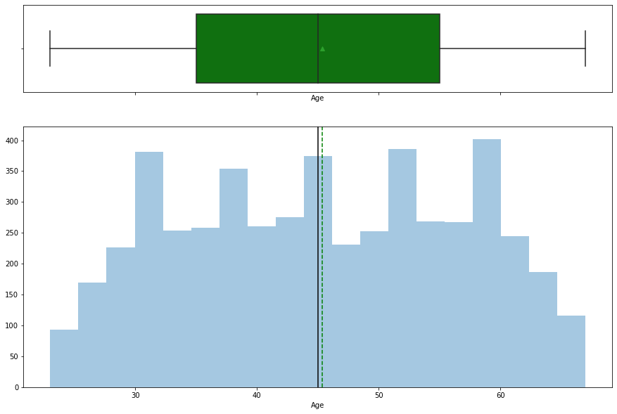

```python
histogram_boxplot(df['Age'])
```

#### Experience

```python
df['Experience'].describe()
```

```
count    5000.000000
mean       20.119600
std        11.440484
min         0.000000
25%        10.000000
50%        20.000000
75%        30.000000
max        43.000000
Name: Experience, dtype: float64
```

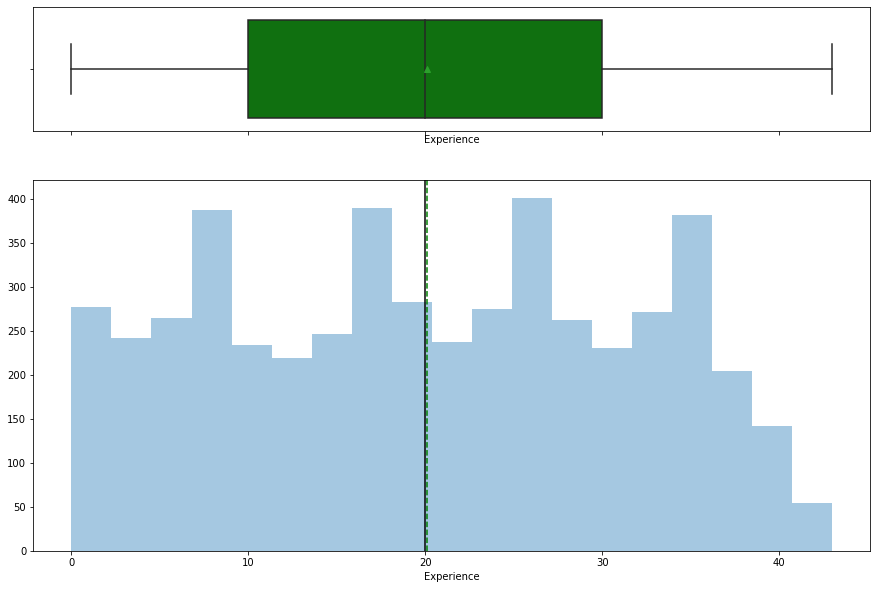

```python
histogram_boxplot(df['Experience'])
```

#### Income

```python
df['Income'].describe()
```

```
count    5000.000000
mean       73.774200
std        46.033729
min         8.000000
25%        39.000000
50%        64.000000
75%        98.000000
max       224.000000
Name: Income, dtype: float64
```

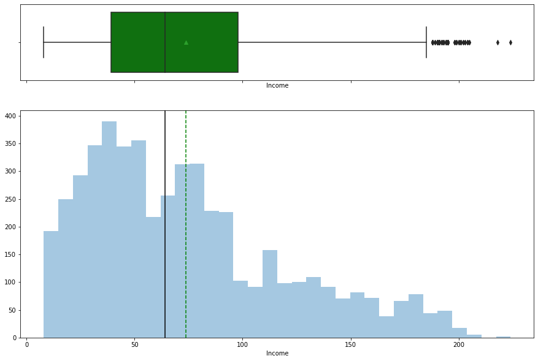

```python
histogram_boxplot(df['Income'])
```

##### Observations

'Income' feature looks to be right-skewed. To handle the skewness and help data behave more like a normal distribution, we will examine whether square root transformation can help

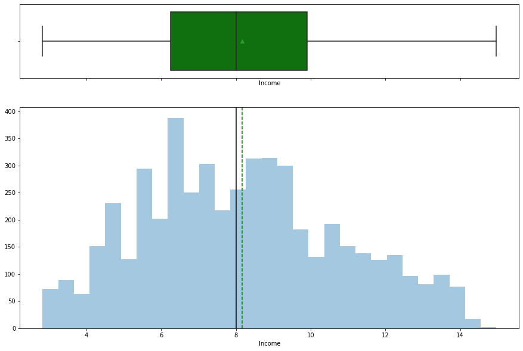

```python
# looking at data distribution when transformed by taking the square root of Income values
histogram_boxplot(np.sqrt(df['Income']))
```

##### Observation

Using the square root of values helped getting data distribution closer to normality.

```python
df['Income' + '_sqrt'] = np.sqrt(df['Income'])
df.drop(['Income'], axis=1, inplace=True)
```

```
count    5000.000000
mean        8.166221
std         2.662416
min         2.828427
25%         6.244998
50%         8.000000
75%         9.899495
max        14.966630
Name: Income_sqrt, dtype: float64
```

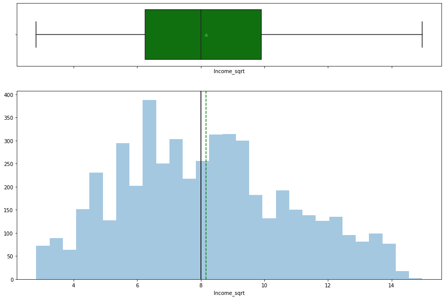

```python
print(df['Income_sqrt'].describe())
histogram_boxplot(df['Income_sqrt'])
```

#### Credit Card Spending

```python
df['CreditCard_Spending'].describe()
```

```
count    5000.000000
mean        1.937938
std         1.747659
min         0.000000
25%         0.700000
50%         1.500000
75%         2.500000
max        10.000000
Name: CreditCard_Spending, dtype: float64
```

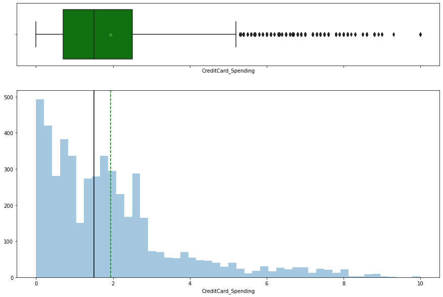

```python
histogram_boxplot(df['CreditCard_Spending'])
```

#### Observations

'CreditCard_Spending' feature looks to be right-skewed. To handle the skewness and help data behave more like a normal distribution, we will examine if square root transformation can help

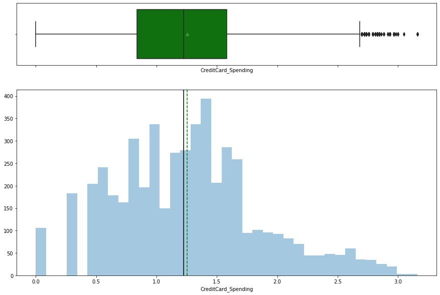

```python
# looking at data distribution when transformed by taking the square root of Income values
histogram_boxplot(np.sqrt(df['CreditCard_Spending']))
```

#### Observation

Using the square root of values helped getting data distribution closer to normality.

```python
df['CreditCard_Spending' + '_sqrt'] = np.sqrt(df['CreditCard_Spending'])
df.drop(['CreditCard_Spending'], axis=1, inplace=True)
```

```
count    5000.000000
mean        1.253347
std         0.605915
min         0.000000
25%         0.836660
50%         1.224745
75%         1.581139
max         3.162278
Name: CreditCard_Spending_sqrt, dtype: float64
```

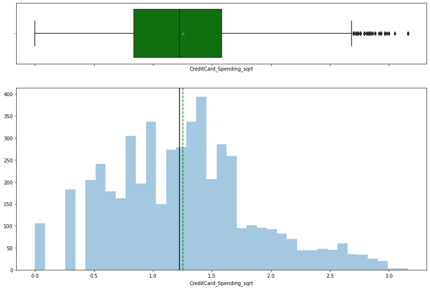

```python
print(df['CreditCard_Spending_sqrt'].describe())
histogram_boxplot(df['CreditCard_Spending_sqrt'])
```

#### Mortgage Value

```python
df['Mortgage_Value'].describe()
```

```
count    5000.000000
mean       56.498800
std       101.713802
min         0.000000
25%         0.000000
50%         0.000000
75%       101.000000
max       635.000000
Name: Mortgage_Value, dtype: float64
```

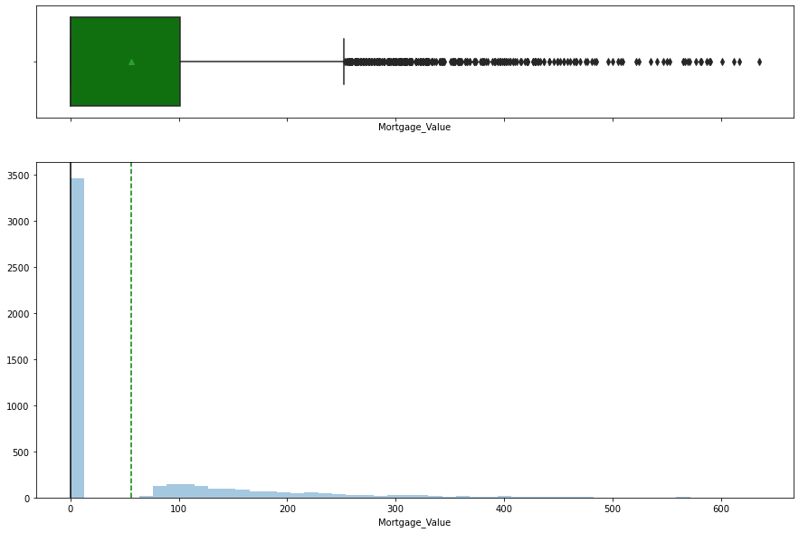

```python
histogram_boxplot(df['Mortgage_Value'])
```

- Seeing that most customers in the dataset do not have a mortgage
- Let's create a feature separating customers who do from customers who do not have a mortgage

##### Reclassifying Mortgage_Value

Between customers who have and who do not have a mortgage

```python
df['Mortgage_Holder'] = df['Mortgage_Value'].apply(lambda x: 1 if x>0 else 0)
```

```python
#dropping Mortgage_Value since reclassified into Mortgage_Holder variable
df.drop(["Mortgage_Value"], axis=1, inplace=True)
```

```python
df["Mortgage_Holder"].value_counts()
```

```
0    3462
1    1538
Name: Mortgage_Holder, dtype: int64
```

- Mortgage_Value successfully recategorized as Mortgage_Holder to indicate customers who have (1) and who do not have (0) a mortgage

## Categorical and Ordinal Features

#### Function to create labeled barplots

```python
def labeled_barplot(data, feature, perc=False, n=None):
    """
    Barplot with percentage at the top

    data: dataframe
    feature: dataframe column
    perc: whether to display percentages instead of count (default is False)
    n: displays the top n category levels (default is None, i.e., display all levels)
    """

    total = len(data[feature])  # length of the column
    count = data[feature].nunique()
    if n is None:
        plt.figure(figsize=(count + 2, 6))
    else:
        plt.figure(figsize=(n + 2, 6))

    plt.xticks(rotation=90, fontsize=15)
    ax = sns.countplot(
        data=data,
        x=feature,
        palette="Paired",
        order=data[feature].value_counts().index[:n].sort_values(),
    )

    for p in ax.patches:
        if perc == True:
            label = "{:.1f}%".format(
                100 * p.get_height() / total
            )  # percentage of each class of the category
        else:
            label = p.get_height()  # count of each level of the category

        x = p.get_x() + p.get_width() / 2  # width of the plot
        y = p.get_height()  # height of the plot

        ax.annotate(
            label,
            (x, y),
            ha="center",
            va="center",
            size=12,
            xytext=(0, 5),
            textcoords="offset points",
        )  # annotate the percentage

    plt.show()  # show the plot
```

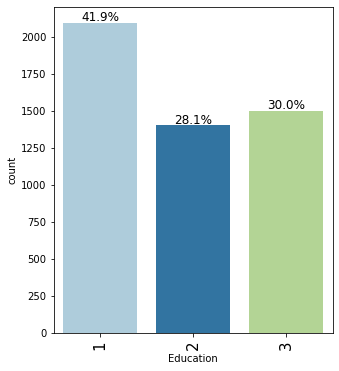

```python
labeled_barplot(df, "Education", perc=True)
```

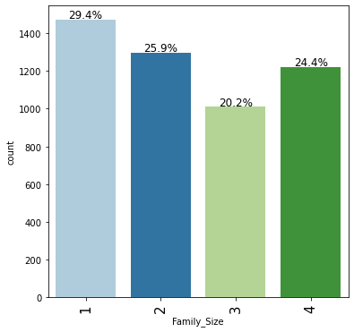

```python
labeled_barplot(df, "Family_Size", perc=True)
```

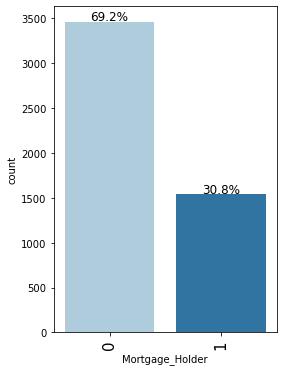

```python
labeled_barplot(df, "Mortgage_Holder", perc=True)
```

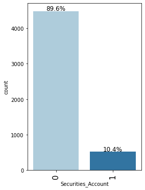

```python
labeled_barplot(df, "Securities_Account", perc=True)
```

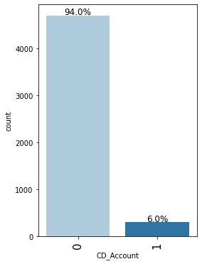

```python
labeled_barplot(df, "CD_Account", perc=True)
```

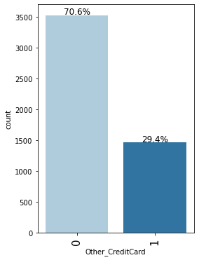

```python
labeled_barplot(df, "Other_CreditCard", perc=True)
```

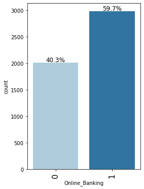

```python
labeled_barplot(df, "Online_Banking", perc=True)
```

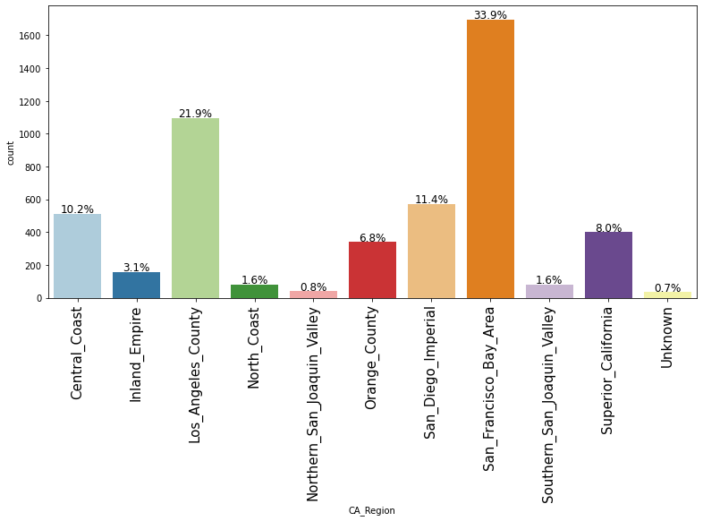

```python
labeled_barplot(df, "CA_Region", perc=True)
```

#### Observations

- Most customers do not currently have a mortgage, securities account, CD account, or credit card from another bank
- 40% of them have at least some college education and 30% have advanced degrees
- In terms of family size, 30% of customers report a family size equal to 1
- 60% of customers report using online banking
- Most customers live in the San Francisco Bay area followed by Los Angeles county

## Observations on the Target Variable: Personal Loan

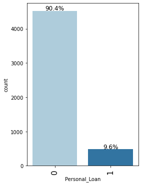

```python
labeled_barplot(df,"Personal_Loan", perc=True)
```

#### Observations

- We can see here that 9.6% of customers accepted a personal loan offer after the previous marketing campaign
- We will use the data here to train and test classification models aimed at predicting the probability that a given customer, with certain characteristics, is to sign up for a loan as a result of the marketing promo

## Bivariate Analysis

### Examining Bivariate Relationships between Personal Loan and Continuous Features

```python
continuous_var = df[['Age', 'Experience', 'Income_sqrt', 'CreditCard_Spending_sqrt', 'Personal_Loan']]
```

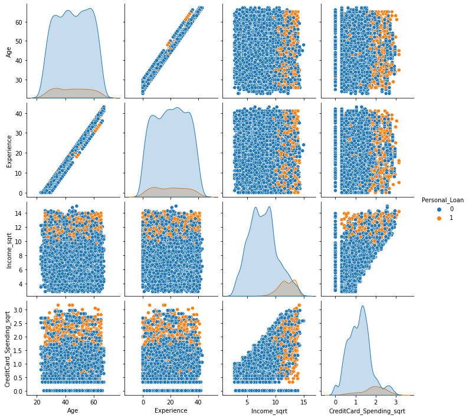

```python
sns.pairplot(continuous_var, hue="Personal_Loan")
plt.show()
```

#### Observations

- We do not see clear differences in terms of age and professional experience between customers who did not accept vs. accepted the loan
- It looks like customers who opted for the loan have higher incomes and credit card spending levels than those who did not accept the offer for a loan

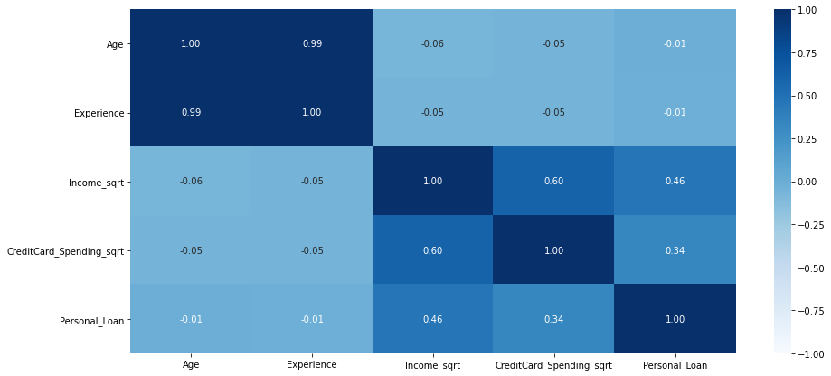

```python
plt.figure(figsize=(15, 7))
sns.heatmap(continuous_var.corr(), annot=True, vmin=-1, vmax=1, fmt=".2f", cmap="Blues")
plt.show()
```

#### Observations

- Accepting the personal loan offer looks to be moderately correlated (positively) with income and credit card spending
- As indicated above, it looks like age and experience have almost no correlation with accepting a personal loan offer

## Examining Relationships between Features and Target Variable

```python
# function to plot stacked bar chart

def stacked_barplot(data, predictor, target):
    """
    Print the category counts and plot a stacked bar chart

    data: dataframe
    predictor: independent variable
    target: target variable
    """
    count = data[predictor].nunique()
    sorter = data[target].value_counts().index[-1]
    tab1 = pd.crosstab(data[predictor], data[target], margins=True).sort_values(
        by=sorter, ascending=False
    )
    print(tab1)
    print("-" * 120)
    tab = pd.crosstab(data[predictor], data[target], normalize="index").sort_values(
        by=sorter, ascending=False
    )
    tab.plot(kind="bar", stacked=True, figsize=(count + 5, 6))
    plt.legend(
        loc="lower left", frameon=False,
    )
    plt.legend(loc="upper left", bbox_to_anchor=(1, 1))
    plt.show()
```

```
Personal_Loan     0    1   All
Education
All            4520  480  5000
3              1296  205  1501
2              1221  182  1403
1              2003   93  2096
------------------------------------------------------------------------------------------------------------------------
```

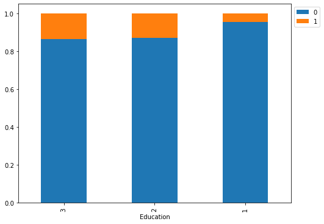

```python
stacked_barplot(df, "Education", "Personal_Loan")
```

#### Observation

- Approximately 14% and 13% of customers with advanced/professional and graduate degrees accepted the personal loan offer in contrast to 4% of customers with undergraduate education

```
Personal_Loan       0    1   All
Mortgage_Holder
All              4520  480  5000
0                3150  312  3462
1                1370  168  1538
------------------------------------------------------------------------------------------------------------------------
```

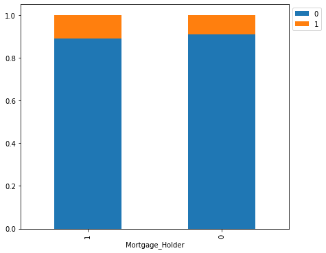

```python
stacked_barplot(df, "Mortgage_Holder", "Personal_Loan")
```

#### Observation

- A slightly greater proportion of mortgage holders vs. non-mortgage holders (11% compared to 9%) accepted the personal loan offer

```
Personal_Loan          0    1   All
Securities_Account
All                 4520  480  5000
0                   4058  420  4478
1                    462   60   522
------------------------------------------------------------------------------------------------------------------------
```

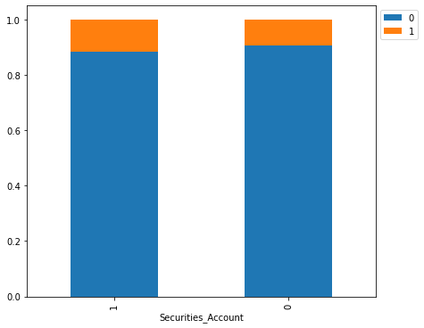

```python
stacked_barplot(df, "Securities_Account", "Personal_Loan")
```

#### Observation

- Customers with and without a securites account accepted the personal loan offer in almost the same proportion

```
Personal_Loan        0    1   All
Other_CreditCard
All               4520  480  5000
0                 3193  337  3530
1                 1327  143  1470
------------------------------------------------------------------------------------------------------------------------
```

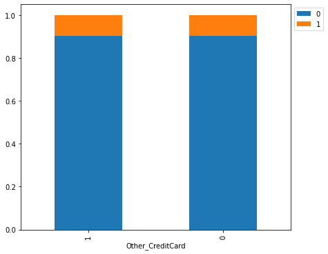

```python
stacked_barplot(df, "Other_CreditCard", "Personal_Loan")
```

#### Observation

- Customers with and without a other bank's credit card accepted the personal loan offer in almost the same proportion

```
Personal_Loan      0    1   All
Online_Banking
All             4520  480  5000
1               2693  291  2984
0               1827  189  2016
------------------------------------------------------------------------------------------------------------------------
```

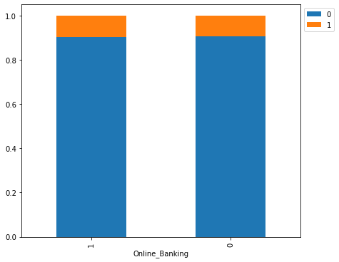

```python
stacked_barplot(df, "Online_Banking", "Personal_Loan")
```

#### Observation

- Customers who use or do not use online banking accepted the personal loan offer in almost the same proportion (both about 9%)

```
Personal_Loan     0    1   All
CD_Account
All            4520  480  5000
0              4358  340  4698
1               162  140   302
------------------------------------------------------------------------------------------------------------------------
```

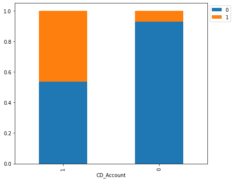

```python
stacked_barplot(df, "CD_Account", "Personal_Loan")
```

#### Observation

- Approximately 46% of customers who have a CD account accepted the personal loan offer compared to 7% of customers without a CD account at the bank

```
Personal_Loan     0    1   All
Family_Size
All            4520  480  5000
4              1088  134  1222
3               877  133  1010
1              1365  107  1472
2              1190  106  1296
------------------------------------------------------------------------------------------------------------------------
```

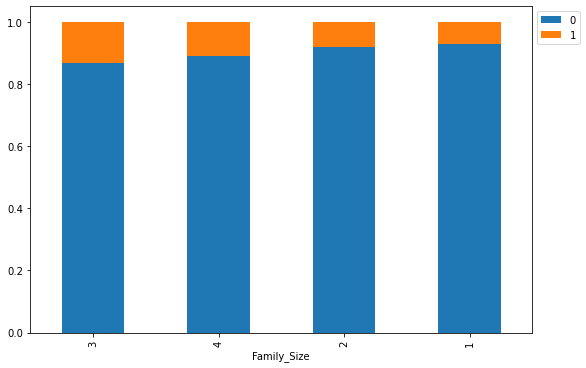

```python
stacked_barplot(df, "Family_Size", "Personal_Loan")
```

#### Observation

- Larger families accepted the personal loan offer in greater proportions

```
Personal_Loan                   0    1   All
CA_Region
All                          4520  480  5000
San_Francisco_Bay_Area       1529  167  1696
Los_Angeles_County            984  111  1095
San_Diego_Imperial            512   59   571
Central_Coast                 461   50   511
Superior_California           368   31   399
Orange_County                 309   30   339
Inland_Empire                 148    9   157
North_Coast                    70    9    79
Southern_San_Joaquin_Valley    71    9    80
Unknown                        31    3    34
Northern_San_Joaquin_Valley    37    2    39
------------------------------------------------------------------------------------------------------------------------
```

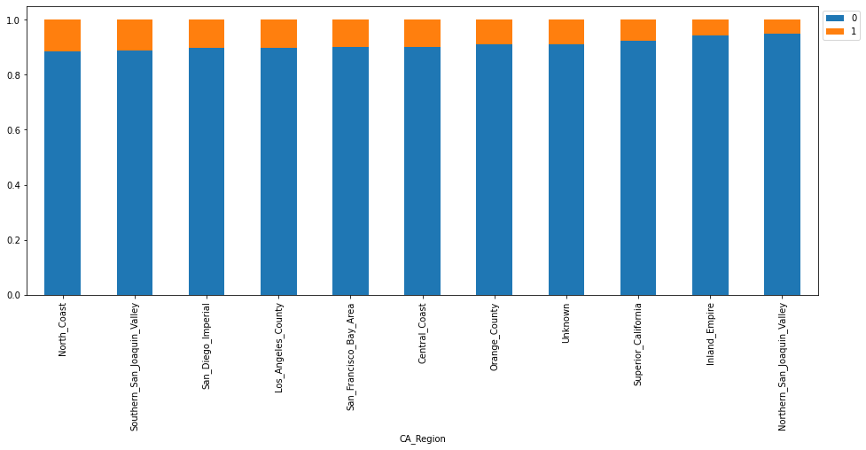

```python
stacked_barplot(df, "CA_Region", "Personal_Loan")
```

#### Observations

- The region with the greatest proportion of personal loan opt ins was the North Coast, followed by Southern San Joaquin Valley
- The region with least proportion of personal loan opt ins was Northern San Joaquin Valley

```python
### function to plot distributions wrt target


def distribution_plot_wrt_target(data, predictor, target):

    fig, axs = plt.subplots(2, 2, figsize=(12, 10))

    target_uniq = data[target].unique()

    axs[0, 0].set_title("Distribution of target for target=" + str(target_uniq[0]))
    sns.histplot(
        data=data[data[target] == target_uniq[0]],
        x=predictor,
        kde=True,
        ax=axs[0, 0],
        color="teal",
        stat="density",
    )

    axs[0, 1].set_title("Distribution of target for target=" + str(target_uniq[1]))
    sns.histplot(
        data=data[data[target] == target_uniq[1]],
        x=predictor,
        kde=True,
        ax=axs[0, 1],
        color="orange",
        stat="density",
    )

    axs[1, 0].set_title("Boxplot w.r.t target")
    sns.boxplot(data=data, x=target, y=predictor, ax=axs[1, 0], palette="gist_rainbow")

    axs[1, 1].set_title("Boxplot (without outliers) w.r.t target")
    sns.boxplot(
        data=data,
        x=target,
        y=predictor,
        ax=axs[1, 1],
        showfliers=False,
        palette="gist_rainbow",
    )

    plt.tight_layout()
    plt.show()
```

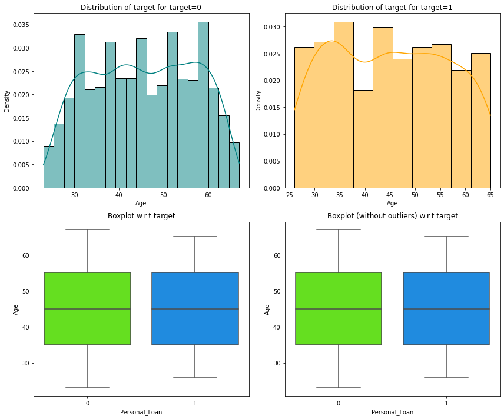

```python
distribution_plot_wrt_target(df, "Age", "Personal_Loan")
```

#### Observation

We hardly see any difference in terms of age between customers who opted in and out of a personal loan

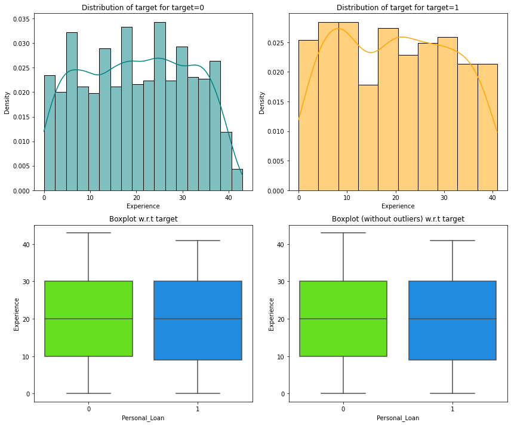

```python
distribution_plot_wrt_target(df, "Experience", "Personal_Loan")
```

#### Observation

As with age, it looks like personal loan opt ins and outs cannot be differentiated much in terms of professional experience

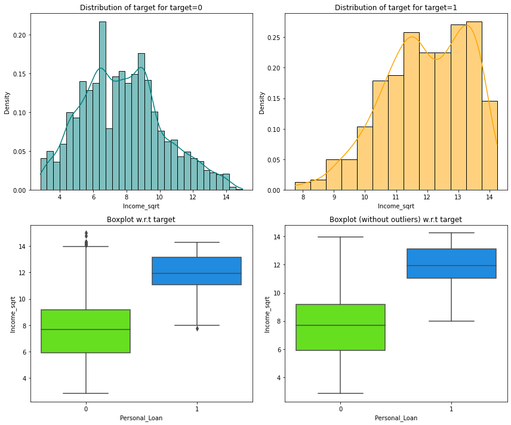

```python
distribution_plot_wrt_target(df, "Income_sqrt", "Personal_Loan")
```

#### Observation

From the histograms and boxplots we observe a clear difference of income between personal loan opt in and opt out customers with the opt in group at higher income levels

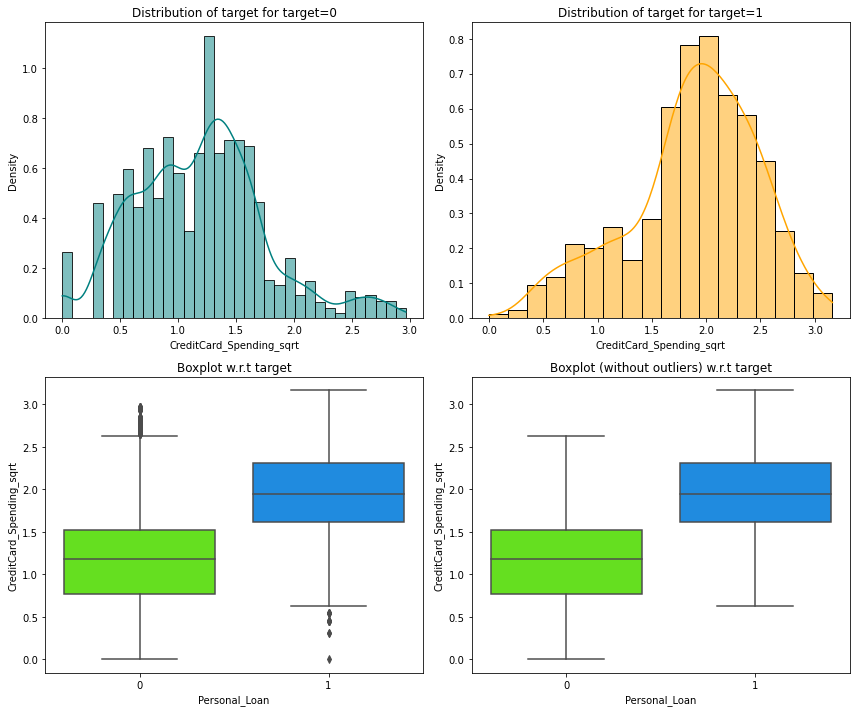

```python
distribution_plot_wrt_target(df, "CreditCard_Spending_sqrt", "Personal_Loan")
```

#### Observation

From the histograms and boxplots we observe a clear difference in terms of credit card spending between personal loan offer opt in and opt out customers with the opt in group at spending on average more

## Summary of EDA

**Data Description:**

- Dependent variable is Personal Loan which is of categorical data type.
- ID is an identifier column and therefore will be dropped from modeling
- ZIPCode column provided means for data extraction from uszipcode library: customer zip codes were associated with state of residence (all from California) and then further with county
- Other than CA_Region feature which is coded as categorical, the remaning features in the dataset are numerical
- There are no missing values

**Data Cleaning:**

- We observed that 52 customers had professional experience lower than 0 years, which is non-sensical. We replaced these with the lowest possible value for experience in the dataset, 0.
- To handle the great number of categorical values in ZIPCode column, we imported data from uszipcode library and observed that all zipcodes were from California, US. We then imported the counties associated with each zip code and pulled data from the California census website to help segment customers into different California regions, thereby reducing the dimension of the zipcode data to 10 distinct values.
- We reduced the Mortgate_Value feature to two categories: mortgage holders and non-mortgage holders
- Square root transformation was performed to handle skeweness in the distribution of values for Income and CreditCard_Spending

**Observations from EDA:**

- `Age`: We did not observe clear differences in terms of age between customers who did not accept vs. accepted the personal loan offered in the previous marketing campaign
- `Experience`: We did not observe clear differences in terms of professional experience between customers who did not accetp vs. accepted the personal loan offer
- `Income`: we observed a clear difference of income between personal loan offer opt in and opt out customers with the opt in group at higher income levels
- `Credit Card Spending`: we observed a clear difference in terms of credit card spending between personal loan offer opt in and opt out customers with the opt-in group spending more monthly on credit cards on average
- `Family Size`: Larger families accepted the personal loan offer in greater proportions than families of smaller size
- `Education`: Approximately 14% and 13% of customers with advanced/professional and graduate degrees accepted the personal loan offer in contrast to 4% of customers with undergraduate education
- `Securities Account`: Customers with and without a securities account opted in for the personal loan offer in almost the same proportion
- `CD Account`: Approximately 46% of customers who have a CD account opted in for the personal loan offer compared to 7% of customers without a CD account
- `Online Banking`: 60% of customers report using online banking. Customers who use or do not use online banking opted in for the personal loan offer in almost the same proportion (both about 9%)
- `Other Credit Card`: Customers who reported using and not using another bank's credit card opted in for the personal loan offer in almost the same proportion
- `CA Region`: Most customers reported in the dataset live in the San Francisco Bay area followed by Los Angeles county. The region with the greatest proportion of personal loan offer opt ins was the North Coast, followed by Southern San Joaquin Valley. The region with least proportion of personal loan offer opt ins was Northern San Joaquin Valley
- `Mortgage Holder`: A slightly greater proportion of mortgage holders vs.non-mortgage holders (11% compared to 9%) accepted the personal loan offer
- `Personal_Loan (target variable)`: 9.6% of customers accepted the personal loan offer after the previous marketing campaign

### Outlier Treatment for Continuous Variables

Any value that is smaller than Q1 - 1.5IQR and greater than Q3 + 1.5IQR is defined as an outlier. We will treat outliers in the dataset by flooring and capping.

- All the values smaller than Q1 - 1.5IQR will be assigned the value equal to Q1 - 1.5IQR (flooring)
- All the values greater than Q3 + 1.5IQR will be assigned the value equal to Q3 + 1.5IQR (capping)

```python
# Let's treat outliers by flooring and capping
def treat_outliers(df, col):
    """
    treats outliers in a variable
    col: str, name of the numerical variable
    df: dataframe
    col: name of the column
    """
    Q1 = df[col].quantile(0.25)  # 25th quantile
    Q3 = df[col].quantile(0.75)  # 75th quantile
    IQR = Q3 - Q1
    Lower_Whisker = Q1 - 1.5 * IQR
    Upper_Whisker = Q3 + 1.5 * IQR

    # all the values smaller than Lower_Whisker will be assigned the value of Lower_Whisker
    # all the values greater than Upper_Whisker will be assigned the value of Upper_Whisker
    df[col] = np.clip(df[col], Lower_Whisker, Upper_Whisker)

    return df


def treat_outliers_all(df, col_list):
    """
    treat outlier in all numerical variables
    col_list: list of numerical variables
    df: data frame
    """
    for c in col_list:
        df = treat_outliers(df, c)

    return df
```